[figure not shown]

# Introduction to Evolution Strategies for Constrained Optimization Prolems

Michael Hellwig, Steffen Finck, and Hans-Georg Beyer

Josef Ressel Centre for Robust Decision Making, Vorarlberg University of Applied Sciences, Dornbirn, Austria.

[figure not shown]

The financial support by the Austrian Federal Ministry of Labour and Economy, the National Foundation for Research, Technology and Development and by the Christian Doppler Research Association is gratefully acknowledged.

### Organizers of this tutorial

Michael Hellwig

Steffen Finck

Hans-Georg Beyer

[figure not shown]

- Senior Scientist and Director of the JR-Centre for Robust Decision Making
- Web profile: [Dr. Michael Hellwig](https://www.fhv.at/mitarbeiter/dr-rer-nat-michael-hellwig-13374)
- Email: [michael.hellwig@fhv.at]
- Lecturer and Senior Scientist at the Vorarlberg University of Applied Sciences
- Web profile: [Dr. Steffen Finck](https://www.fhv.at/mitarbeiter/dr-ing-steffen-finck-13251)
- Email: [steffen.finck@fhv.at]
- Research Professor at the Research Centre Business Informatics
- Web profile: [Prof. Hans-Georg Beyer](https://www.fhv.at/mitarbeiter/prof-fh-dipl-ing-dr-rer-nat-habil-hans-georg-beyer-13253)
- Email: [hans-georg.beyer@fhv.at]

## Content of this tutorial

- Introduction to Evolution Strategies and Constrained Optimization
  - Tutorial motivation
  - A general continuous single-objective constrained optimization problem (COP)
  - The Matrix Adaptation Evolution Strategy (MA-ES)
  - Brief overview of constrained benchmarks
- Treatment of constraints
  - Constraint handling techniques
    - Penalty approaches
    - Augmented Lagragian methods
    - Repair techniques
    - Constraint relaxation
  - Comparisons on two simple test COPs
    - Demo of experiments
- Interactive Session & Roundup
  - Download / Setup
  - Hands-on application of several techniques
- Session round-up
  - Successful ES in constrained environments
  - Theoretical work on ES for COPs

### A general continuous single-objective constrained optimization problem (COP)

$$ \begin{equation} \begin{aligned} \min \:\: & f(\mathbf{y}) & & \qquad \gets \quad \textrm{objective function}\\ s.t. \:\: & g_i(\mathbf{y}) \leq 0, & i=1,\dots,l,\: & \qquad\gets \quad \textrm{inequality constraints}\\ & h_j(\mathbf{y}) = 0, & j=1,\dots,k, & \qquad\gets \quad \textrm{equality constraints}\\ & \mathbf{y} \in S = \left[\check{\mathbf{y}},\hat{\mathbf{y}}\right]\subseteq \mathbb{R}^N. & & \qquad\gets \quad \textrm{box constraints} \end{aligned} \end{equation} $$

- The continuous (non-)linear objective function is given by $f : \mathbb{R}^N \to \mathbb{R}$.
- $\mathbf{y} \in \mathbb{R}^N$ represents the $N$-dimensional real-valued parameter vector.
- The total number of (non-)linear constraint functions is $m=k+l$.
- The box constraints represent lower ($\check{\mathbf{y}}$) and upper bounds ($\hat{\mathbf{y}}$) on the parameter vector components.

### 2-D examples of contraint types

A single **linear inequality** visualized in a 2-dimensional search space $\mathbb{R^2}$.

[figure not shown]

### 2-D examples of contraint types

A single **non-linear inequality** visualized in a 2-dimensional search space $\mathbb{R^2}$.

[figure not shown]

### 2-D examples of contraint types

A single **non-linear equality** visualized in a 2-dimensional search space $\mathbb{R^2}$.

[figure not shown]

### 2-D examples of contraint types

Combination of **linear inequality** and **non-linear equality constraint** .

[figure not shown]

### The Matrix Adaptation Evolution Strategy (MA-ES)

- introduced by ([H.-G. Beyer and B. Sendhoff, 2017](https://doi.org/10.1109/TEVC.2017.2680320))
- represents a simplification of the CMA-ES ([Hansen and Ostermeier, 2001](https://doi.org/10.1162/106365601750190398))
  - avoids the construction of the covariance matrix $C$
  - instead uses a transformation matrix $M$ (representing $\sqrt{C}$)
  - spares the need for spectral or Cholesky decomposition
  - uses a single search path for the mutation strength $\sigma$ as well as the $M$ update
  - reduces the complexity of code and the number of strategy parameters
- exhibits a performance similar to CMA-ES on most test problems
  - assessed on 8 classic test function and on the [BBOB test bed](https://numbbo.github.io/coco/testsuites/bbob)
- builds the core search driver of the proposed strategy for solving (COP).

### The Matrix Adaptation Evolution Strategy (MA-ES)

[figure not shown]

### The Matrix Adaptation Evolution Strategy (MA-ES)

[figure not shown]

### The Matrix Adaptation Evolution Strategy (MA-ES)

[figure not shown]

### The Matrix Adaptation Evolution Strategy (MA-ES)

[figure not shown]

### The Matrix Adaptation Evolution Strategy (MA-ES)

[figure not shown]

### The Matrix Adaptation Evolution Strategy (MA-ES)

[figure not shown]

### The Matrix Adaptation Evolution Strategy (MA-ES)

[figure not shown]

### Overview of testbeds

- **COCO BBOB-constrained**
  - [Duffose et al. 2022](https://numbbo.github.io/coco-doc/bbob-constrained) and
  - [numbbo/coco github](https://github.com/numbbo/coco)
- **CEC competitions** on single-objective continuous constrained optimization
  - (P. N. Suganthan, 2006, 2010, 2017, and 2020) [github of P. N. Suganthan](https://github.com/P-N-Suganthan?tab=repositories)
- **The Rotated Klee-Minty Problem**
  - ( [M. Hellwig and H.-G. Beyer, 2018](https://doi.org/10.1145/3319619.3326805) )
- **Portfolio Optimization**
  - [Z. X. Loke et al., 2023](https://ieeexplore.ieee.org/abstract/document/10087257)
  - [H.-G. Beyer, S. Finck and T. Breuer, 2014](https://doi.org/10.1016/j.swevo.2014.03.002) and
  - [H.-G. Beyer and S. Finck, 2012](https://doi.org/10.1109/TEVC.2011.2169967)
- few dedicated python packages like
  - [DEAP](https://deap.readthedocs.io/en/master/index.html)

## 2. Treatment of constraints

- **Constraint Handling techniques**
  - Penalty approaches
  - Augmented Lagragian methods
  - Repair techniques
  - Constraint relaxation approaches
- **The $\epsilon$MAg-ES**
- **Comparison on two simple test COPs**
  - Test COPs
  - Experimentation

#### **Constraint Handling techniques**

```
- Bound-constraint handling
- Penalty approaches
- Augmented Lagragian methods
- Repair techniques
- Constraint relaxation approaches
```

### Penalty Approaches

- *interior* and *exterior* approaches
- depend on *constraint violations* $cv$ of inequality constraints $g_i$ and equality constraints $h_i$ $$cv(\mathbf{x}) = \sum_i r_i \max[0, g_i(\mathbf{x})]^\beta + \sum_j c_j |h_j(\mathbf{x})|^\gamma \text{ with } \beta, \gamma \ge 1 \text{ and } r_i, c_j > 0 $$
- transform the constrained OP into unconstrained OP (fitness level approach) $$\tilde{f}(\mathbf{x}) = f(\mathbf{x}) + cv(\mathbf{x})$$
- common values: $\beta=2$ and $\gamma = 1$
- Advantages:
  - easy to implement
  - wide variety of possible methods
  - use of algorithms for unconstrained problems
- Drawbacks:
  - generalization over different problem classes
  - additional parameters (additional tuning efforts)
  - change of problem structure (increase in ill-conditioning due to large penalty values)

**Penalty Approaches**

- *Death Penalty*
  - sample new solution until **only** feasible are in the population
  - easy to implement
  - high sampling effort and premature stagnation
- *Static Penalty*:
  - uses constant values $r_i$ and $c_j$ in constraint violation measures
  - sensitivity in regions close to the feasible border
- *Dynamic Penalty*:
  - often related with the generation number (like a cooling schedule)
  - from small values (*soft penalties*) to larger values (*hard penalties*) to allow exploration at the start and focus on exploitation at the end
- *Adaptive Penalty*:
  - use of fitness values
  - aiming for balance between feasible and infeasible solutions
  - correlation between feedback from population and optimization progress
- survey papers: [E. Mezura-Montes and C. Coello Coello, 2011](https://doi.org/10.1016/j.swevo.2011.10.001) and [H. J. C. Barbosa, A. C. C. Lemonge and H. S. Bernardino, 2015](https://doi.org/10.1007/978-81-322-2184-5_1)

### Augmented Lagragian methods

- Idea: use of Lagrangian Multiplier $\gamma$ (Karush-Kuhn-Tucker conditions) $$ \begin{equation} \tilde{f}(\mathbf{x}, \mathbf{\gamma}, \mathbf{\omega}) = f(\mathbf{x}) + \mathbf{\gamma}^T \left[\begin{array} \mathbf{g}(\mathbf{x}) \\ \mathbf{h}(\mathbf{x}) \end{array}\right] \end{equation} $$
- special form of adaptive penalty
- equality constraints are transformed: $$h(\mathbf{x}) \rightarrow g(\mathbf{x}) = |h(\mathbf{x})| - \epsilon \le 0$$ or $$h(\mathbf{x}) \rightarrow g_1(\mathbf{x}) = h(\mathbf{x}) \le 0 \text{ and } g_2(\mathbf{x}) = -h(\mathbf{x}) \le 0$$
- augmented objective function: $$ \tilde{f}(\mathbf{x}, \mathbf{\gamma}, \mathbf{\omega}) = f(\mathbf{x}) + \sum_i\begin{cases} \gamma_i g_i(\mathbf{x}) + \dfrac{\omega_i}{2}g_i(\mathbf{x})^2 \text{ if } \gamma_i + \omega_i g_i(\mathbf{x}) \ge 0 \\ -\dfrac{\gamma_i^2}{2 \omega_i} \end{cases} \text{ with } \gamma_i, \omega_i > 0$$
- necessary conditions for $\gamma_i, \omega_i$ exist, such that the global optimum of the COP is a local optimum of $\tilde{f}(\mathbf{x}, \mathbf{\gamma}, \mathbf{\omega})$
- problem is generall well-conditioned if $\omega_i$ is small (linear convergence for linearly constrained problems with step-size adapative ES [A. Atama, A. Auger and N. Hansen, 2017](https://doi.org/10.1145/3040718.3040732)
- aim: add adaptive methods to converge towards correct Lagrangian multiplier $\gamma_i$

### Augmented Lagragian methods

pseudocode of Method 1 of AL-CMA-ES by [P. Dufosse and N. Hansen, 2021](https://dl.acm.org/doi/10.1145/3449639.3459340)

[figure not shown]

- dAL-ES: Direct Augmented Lagrangian Evolution Strategy
  - [J. Porter and D. V. Arnold, 2024](https://doi.org/10.1145/3638529.3654012)
  - direct estimation of Lagrange Multipliers via approximation of gradients
  - competitive with AL-CMA-ES on several tested problems
- survey on AL approaches: [J. Porter, 2022](https://dalspace.library.dal.ca/handle/10222/81935)

### Repair techniques

- Aim to correct constraint violations of candidate solutions created during the search
  - Approaches may require additional information on the structure of the feasible region
- Various types of repair exist:
  - Projection onto the boundary of the feasible region
  - Reflection into the feasible region
  - Truncation of the mutation step to ensure feasible offspring
- Aside from empirical experimentation, there are theoretical findings w.r.t. benefits of certain repair mechanisms under specifi assuptions
  - e.g., ([M. Hellwig and D. Arnold, 2016](https://doi.org/10.1162/EVCO_a_00139)) show the advantage of linear projection over relfection and truncation mechanisms for the $(1,\lambda)-ES$ in a simple constrained environment
    - only projection is able to ensure continuous progress for arbitrarily small constraint angles

[figure not shown]

### Repair techniques

A more general repair technique is the so-called **Gradient-based repair** ([T. Takahama and S. Sakai, 2010](https://doi.org/10.1109/CEC.2010.5586484)).

Consider all $m$ constraint function values at an infeasible $\mathbf{y} \notin M$ $$ C(\mathbf{y}) = \left( g_1(\mathbf{y}),\dots,g_l(\mathbf{y}),h_1(\mathbf{y}),\dots,h_k(\mathbf{y}) \right)\top$$

and determine the amount of constraint violation in each component as $$ \Delta C(\mathbf{y}) = \left( \max(0,g_1(\mathbf{y})),\dots,\max(0,g_l(\mathbf{y})),h_1(\mathbf{y}),\dots,h_k(\mathbf{y}) \right)\top$$

One can then determine the desired change $\Delta \mathbf{y}$ towards a feasible parameter vector $$\tilde{\mathbf{y}} = \mathbf{y} + \Delta\mathbf{y} \in M$$ by linearly expanding the function $C(\mathbf{y})$. This yields $$ \Delta \mathbf{y} = - {\nabla C(\mathbf{y})}^{-1} \cdot \Delta C(\mathbf{y}) $$ with ${\nabla C(\mathbf{y})}^{-1}$ being the pseudo-inverse of the Jacobian $\nabla C(\mathbf{y}) $ of $C(\mathbf{y})$.

### Repair techniques

A more general repair technique is the so-called **Gradient-based repair** ([T. Takahama and S. Sakai, 2010](https://doi.org/10.1109/CEC.2010.5586484)).

[figure not shown]

- The repair mechanism performs a **descending step** on the hyper-surface of all **combined** constraint functions
  - This step requires the approximation of the corresponding Jacobian matrix through finite differences
  - Depending on the problem dimension the approximation is quite costly in terms of `fevals`
    - Thus it is only performed erraticly (with certain probability, etc.)
- The repair step does not ensure to yield a feasible candiate solution directly.
  - Yet, by consecutive application **Gradient-based repair** gradually approaches the feasible region $M$

### Constraint relaxation approaches

- Such methods dislocate the boundary of the feasible region $M$.
  - Previously infeasible parameter vectors are considered (temporarily) feasible during the search.
- Solvers may thus operate outside the original feasible region.
- The relaxation is usually gradually sharpened to ultimately guarantee feasibility.

[figure not shown]

### Constraint relaxation approaches

A common constrain relaxation technique is **$\epsilon$-level ordering** [T. Takahama and S. Sakai, 2006](https://doi.org/10.1109/ICSMC.2006.385209)

- An initial $\epsilon^{(0)}$ threshold is determined (e.g., the average or median constraint violation of the initial population)
- Two candidate solutions $y_i, y_j \in \mathbb{R}^{N}$ with objective function values $f_i, f_j$ and corresponding constraint violation values $\nu_i, \nu_j$ are then compared according to

  $$ y_i \leq_\epsilon y_j \quad \colon\Leftrightarrow \quad \left\{ \begin{matrix} f_i \leq f_j& \quad \textrm{if } \nu_i \leq\epsilon^{(g)} \: \& \: \nu_j \leq \epsilon^{(g)}\\f_i \leq f_j& \quad \textrm{if } \nu_i = \nu_j \\\nu_i < \nu_j &\quad \textrm{otherwise } \end{matrix} \right.$$

  ```
    - Two $\epsilon$-feasible solutions are ranked w.r.t. their objective function values.
    - Two $\epsilon$-infeasible solutions are ordered based on their constraint violations.
    - Ties are resolved by considering the objective function values.
  ```

- The $\epsilon^{(g)}$ threshold is gradually reduced towards zero during the search process.
- For $\epsilon^{(g)} = 0 $ the **$\epsilon$-level ordering** resembles the **lexicographic ordering** w.r.t. constraint violation and objective function values.

## The $\epsilon$MAg Evolution Strategy

- represents a possible MA-ES variant for general COPs
- applies a number of modifications to successfully treat COPs
  1. an order relation that distinguishes feasible and infeasible solutions
  2. a box-constraint handling approach
  3. a erratically applied repair step (based on gradient approximation)
  4. a readjustment step for repaired mutation vectors (due to 2. and 3.)
     - selected offspring pass their mutation vector to the $p_\sigma$ and $\mathbf{M}$ update
     - due to repair the originally sampled mutation vector can introduce wrong information $$\mathbf{d}_l^{(g)} \gets \left(\mathbf{y}_l^{(g)} - \mathbf{y}^{(g)} \right) / \sigma^{(g)} \qquad \textrm{and} \qquad \mathbf{z}_l^{(g)} = \mathbf{M}^{-1} \mathbf{d}_l^{(g)} $$
  5. a regularization step for the transformation matrix $\mathbf{M}$ (due to 4.)
     - prevents numerical instabilities when computing the pseudo inverse $\mathbf{M}^{-1}$ of $\mathbf{M}$
     - workaround: $\mathbf{M} \gets\mathbf{I} $ if $\mathbf{M}^{-1}$ fails

## The $\epsilon$MAg Evolution Strategy

[figure not shown]

## The $\epsilon$MAg Evolution Strategy

### Demonstrations on test COPs

```
- Test COPs
    - a simple linear constraint
    - selected test functions of the CEC 2017 competitions
    - real world problems
- Experimentation
```

### Demonstrations on simple COPs

```
- Test COPs
    - a simple linear constraint
```

$$ \begin{equation} \begin{aligned} \min \:\: & f(\mathbf{y}) = \sum_{i=1}^{N} \mathbf{y}_i^2 & & \gets \textrm{Sphere function} \\ s.t. \:\: & g(\mathbf{y}) = 25-\sum_{i=1}^{N} \mathbf{y}_i \leq 0, & & \gets \textrm{linear inequality constraint} \\ & \mathbf{y} \in \mathbb{R}^N. & & \end{aligned} \end{equation} $$

### Demonstrations on simple COPs

```
- Test COPs
    - selected test functions of the CEC 2017 competition
```

| Constraint function C01 | Constraint function C03 | Constraint function f6 | Constraint function C11 |
| --- | --- | --- | --- |

| $$ \begin{equation} \begin{aligned} \min \:\: & f(\mathbf{y}) = \sum_{i=1}^{N} \left( \sum_{j=1}^i (\mathbf{y}_j-\mathbf{y}^*_j)^2 \right) & & \\ s.t. \:\: & g(\mathbf{y}) = \sum_{i=1}^{N} \left[ (\mathbf{y}_i-\mathbf{y}^*_i)^2 +5000\cdot\cos\left(0.1\pi(\mathbf{y}_i-\mathbf{y}^*_i)\right) -4000 \right] \leq 0, & & \\ & \mathbf{y} \in [-100,100]^N \subset \mathbb{R}^N. & & \end{aligned} \end{equation} $$ | $$ \begin{equation} \begin{aligned} \min \:\: & f(\mathbf{y}) = \sum_{i=1}^{N} \left( \sum_{j=1}^i (\mathbf{y}_j-\mathbf{y}^*_j)^2 \right) & & \\ s.t. \:\: & g(\mathbf{y}) = \sum_{i=1}^{N} \left[ (\mathbf{y}_i-\mathbf{y}^*_i)^2 +5000\cdot\cos\left(0.1\pi(\mathbf{y}_i-\mathbf{y}^*_i)\right) -4000 \right] \leq 0, & & \\ & h(\mathbf{y}) =- \sum_{i=1}^{N} (\mathbf{y}_i-\mathbf{y}^*_i)\cdot\sin\left(0.1\pi(\mathbf{y}_i-\mathbf{y}^*_i)\right) = 0, & & \\ & \mathbf{y} \in [-100,100]^N \subset \mathbb{R}^N. & & \end{aligned} \end{equation} $$ | $$ \begin{equation} \begin{aligned} \min \:\: & f(\mathbf{y}) = \sum_{i=1}^{N} \mathbf{y}_i^2 & & \\ s.t. \:\: & g(\mathbf{y}) = 25-\sum_{i=1}^{N} \mathbf{y}_i , & & \\ & \mathbf{y} \in \mathbb{R}^N. & & \end{aligned} \end{equation} $$ | $$ \begin{equation} \begin{aligned} \min \:\: & f(\mathbf{y}) = \sum_{i=1}^{N} \mathbf{y} & & \\ s.t. \:\: & g(\mathbf{y}) = \prod_{i=1}^{N} \mathbf{y}_i \leq 0 , & & \\ & h(\mathbf{y}) = \sum_{i=1}^{N-1} \left(\mathbf{y}_i - \mathbf{y}_{i+1}\right)^2 = 0, & & \\ & \mathbf{y} \in [-100,100]^N \subset \mathbb{R}^N. & & \end{aligned} \end{equation} $$ |

```python
from maes import MAES
from maes import sphere
import numpy as np
import matplotlib.pyplot as plt
```

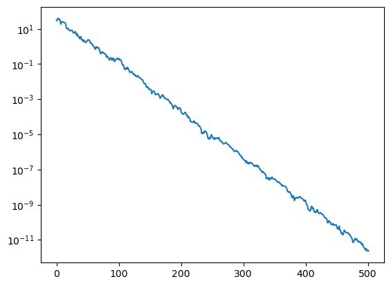

```python
test = MAES(np.ones(30),3,10,1,500,100000)
plt.figure
plt.yscale("log")
plt.plot(test[2])
```

### C. Interactive Session

- Download the **Experiment Package** (Python 3 envoronment needed)
  - QR code for download
  - **Content**
    - files
    - resources
- **Interactive breakout**
  - Try different combinations on the three provided test COPs
- Overview of **ES advantages** in COP environments

**Download the Experiment Package**

- QR code for download
- **Content**
  - files
  - resources

**Interactive breakout**

- Try different combinations on the three provided test COPs

Overview of **ES advantages** in COP environments